# Assignment 1 - Data set selection and initial processing

Khaled Elemam

##### Note: The code used in this assignment is adopted from BCB420 Winter 2021 lectures 3 to 5.

#### Install and load required libraries for the workflow.

```r
if (!requireNamespace("BiocManager", quietly = TRUE)) install.packages("BiocManager")
if (!requireNamespace("GEOmetadb", quietly = TRUE))  BiocManager::install("GEOmetadb")
if (!requireNamespace("edgeR", quietly = TRUE))     BiocManager::install("edgeR")
if (!requireNamespace("biomaRt", quietly = TRUE))  BiocManager::install("biomaRt")
if (!requireNamespace("tidyverse", quietly = TRUE)) install.packages("tidyverse")
if (!requireNamespace("gdtools", quietly = TRUE))    install.packages("gdtools")
if (!requireNamespace("kableExtra", quietly = TRUE))  install.packages("kableExtra")
if (!requireNamespace("data.table", quietly = TRUE))  install.packages("data.table")

library(knitr)
library(GEOmetadb)
library(edgeR)
library(biomaRt)
library(dplyr)
library(kableExtra)
library(data.table)
```

# 1. Data exploration

#### 1.1 GEO description of the dataset:

```r
gse <- getGEO("GSE151879",GSEMatrix=FALSE)
```

```r
kable(data.frame(head(Meta(gse))), format = "html")
```

| contact_address | contact_city | contact_country | contact_department | contact_email | contact_institute |
| --- | --- | --- | --- | --- | --- |
| A 827B, 1300 York Ave | New York | USA | Surgery | shuibing.chen@gmail.com | Weill Cornell Medical College |

#### 1.2 Information about the platform:

```r
current_gpl <- names(GPLList(gse))[1]
current_gpl_info <- Meta(getGEO(current_gpl))
```

**Platform title** : Illumina NextSeq 500 (Homo sapiens)  
**GEO accession** : GPL18573  
**Submission date** : Apr 15 2014  
**Last update date** : Mar 26 2019  
**Organism** : Homo sapiens  
**Number of GEO datasets that use this techology** : 4628  
**Number of GEO samples that use this technology** : 198425

#### 1.3 Get the expression data:

```r
sub_dir <- "GSE151879"
p <-file.path(getwd(), sub_dir)

#if the data exists no need to download it again
if (dir.exists(p)){
  setwd(p)
  Adult_path <- "GSE151879_raw_counts_genes.Adult_human_cardiomyocytes.txt.gz"
  Macrophages_path <- "GSE151879_raw_counts_genes.Macrophages.txt.gz"
  hESC_path <- "GSE151879_raw_counts_genes.hESC-derived_cardiomyocytes.txt.gz"

  Adult_human_CM = read.delim(Adult_path,header=TRUE,check.names = FALSE)
  Macrophages = read.delim(Macrophages_path,header=TRUE,check.names = FALSE)
  hESC_CM = read.delim (hESC_path,header=TRUE,check.names = FALSE)

} else{

  sfiles = getGEOSuppFiles("GSE151879")
  fnames = rownames(sfiles)

  # there are three supplemental files
  Adult_human_CM = read.delim(fnames[1],header=TRUE,check.names = FALSE)
  Macrophages = read.delim(fnames[2],header=TRUE,check.names = FALSE)
  hESC_CM = read.delim(fnames[3],header=TRUE,check.names = FALSE)

}

kable(Adult_human_CM[1:5,], format = "html")
```

| gene_id | Adult_human_cardiomyocytes_Mock_1 | Adult_human_cardiomyocytes_Mock_2 | Adult_human_cardiomyocytes_Mock_3 | Adult_human_cardiomyocytes_SARS-CoV2_1 | Adult_human_cardiomyocytes_SARS-CoV2_2 | Adult_human_cardiomyocytes_SARS-CoV2_3 |
| --- | --- | --- | --- | --- | --- | --- |
| ENSG00000000003 | 1014 | 841 | 983 | 1267 | 1064 | 1440 |
| ENSG00000000005 | 0 | 0 | 0 | 0 | 0 | 0 |
| ENSG00000000419 | 1541 | 1419 | 1722 | 1796 | 1767 | 2208 |
| ENSG00000000457 | 602 | 544 | 582 | 756 | 685 | 864 |
| ENSG00000000460 | 128 | 118 | 123 | 238 | 222 | 255 |

```r
kable(Macrophages[1:5,], format = "html")
```

| gene_id | Macrophages_Mock_1 | Macrophages_Mock_2 | Macrophages_Mock_3 | Macrophages_SARS-CoV2_1 | Macrophages_SARS-CoV2_2 | Macrophages_SARS-CoV2_3 |
| --- | --- | --- | --- | --- | --- | --- |
| ENSG00000000003 | 13 | 23 | 13 | 27 | 8 | 15 |
| ENSG00000000005 | 0 | 0 | 0 | 0 | 0 | 0 |
| ENSG00000000419 | 378 | 346 | 407 | 444 | 217 | 410 |
| ENSG00000000457 | 185 | 177 | 232 | 195 | 88 | 237 |
| ENSG00000000460 | 93 | 122 | 169 | 110 | 53 | 134 |

```r
kable(hESC_CM[1:5,], format = "html")
```

| gene_id | hESC-derived_cardiomyocytes_Mock_1 | hESC-derived_cardiomyocytes_Mock_2 | hESC-derived_cardiomyocytes_Mock_3 | hESC-derived_cardiomyocytes_SARS-CoV2_1 | hESC-derived_cardiomyocytes_SARS-CoV2_2 | hESC-derived_cardiomyocytes_SARS-CoV2_3 |
| --- | --- | --- | --- | --- | --- | --- |
| ENSG00000000003 | 823 | 1103 | 679 | 187 | 151 | 173 |
| ENSG00000000005 | 56 | 90 | 44 | 1 | 0 | 0 |
| ENSG00000000419 | 437 | 593 | 404 | 153 | 117 | 90 |
| ENSG00000000457 | 140 | 228 | 141 | 150 | 141 | 119 |
| ENSG00000000460 | 131 | 186 | 89 | 36 | 35 | 37 |

#### Note: Out of the 3 experiments/files I chose the Adult human cardiomayocytes dataset for my analysis.

#### 1.4 Overview statistics for dataset:

```r
dim(Adult_human_CM)
```

```
## [1] 57916     7
```

```r
colnames(Adult_human_CM)
```

```
## [1] "gene_id"
## [2] "Adult_human_cardiomyocytes_Mock_1"
## [3] "Adult_human_cardiomyocytes_Mock_2"
## [4] "Adult_human_cardiomyocytes_Mock_3"
## [5] "Adult_human_cardiomyocytes_SARS-CoV2_1"
## [6] "Adult_human_cardiomyocytes_SARS-CoV2_2"
## [7] "Adult_human_cardiomyocytes_SARS-CoV2_3"
```

```r
summary(Adult_human_CM)
```

```
##    gene_id          Adult_human_cardiomyocytes_Mock_1
##  Length:57916       Min.   :      0
##  Class :character   1st Qu.:      0
##  Mode  :character   Median :      0
##                     Mean   :    804
##                     3rd Qu.:     21
##                     Max.   :4973574
##  Adult_human_cardiomyocytes_Mock_2 Adult_human_cardiomyocytes_Mock_3
##  Min.   :      0                   Min.   :      0
##  1st Qu.:      0                   1st Qu.:      0
##  Median :      0                   Median :      0
##  Mean   :    736                   Mean   :    780
##  3rd Qu.:     20                   3rd Qu.:     20
##  Max.   :4569012                   Max.   :4895063
##  Adult_human_cardiomyocytes_SARS-CoV2_1 Adult_human_cardiomyocytes_SARS-CoV2_2
##  Min.   :      0                        Min.   :      0
##  1st Qu.:      0                        1st Qu.:      0
##  Median :      0                        Median :      0
##  Mean   :    981                        Mean   :    909
##  3rd Qu.:     25                        3rd Qu.:     22
##  Max.   :8006190                        Max.   :7171362
##  Adult_human_cardiomyocytes_SARS-CoV2_3
##  Min.   :      0
##  1st Qu.:      0
##  Median :      0
##  Mean   :   1024
##  3rd Qu.:     24
##  Max.   :7560544
```

#### 1.5 Filter weakly expressed features

```r
#translate out counts into counts per million using the edgeR package
cpms = cpm(Adult_human_CM[,2:7])
rownames(cpms) <- Adult_human_CM[,1]
# get rid of low counts
keep = rowSums(cpms >1) >=3
Adult_human_CM_filtered = Adult_human_CM[keep,]
dim(Adult_human_CM_filtered)
```

```
## [1] 13200     7
```

#### 1.6 Define the groups

```r
samples <- data.frame(lapply(colnames(Adult_human_CM_filtered)[2:7],
                             FUN=function(x){unlist(strsplit(x, split = "\\_"))[c(4,5)]}))
colnames(samples) <- colnames(Adult_human_CM_filtered)[2:7]
rownames(samples) <- c("condition","number")
samples <- data.frame(t(samples))
samples
```

|  | condition | number |
| --- | --- | --- |
| Adult_human_cardiomyocytes_Mock_1 | Mock | 1 |
| Adult_human_cardiomyocytes_Mock_2 | Mock | 2 |
| Adult_human_cardiomyocytes_Mock_3 | Mock | 3 |
| Adult_human_cardiomyocytes_SARS-CoV2_1 | SARS-CoV2 | 1 |
| Adult_human_cardiomyocytes_SARS-CoV2_2 | SARS-CoV2 | 2 |
| Adult_human_cardiomyocytes_SARS-CoV2_3 | SARS-CoV2 | 3 |

# 2. Identifier mapping

#### 2.1 Connect to ensemble mart and limit to humans dataset

```r
ensembl <- useMart("ensembl")
ensembl = useDataset("hsapiens_gene_ensembl",mart=ensembl)
```

#### 2.2 Map human ensemble IDs to hgnc symbols

```r
conversion_stash <- "Adult_human_CM_id_conversion.rds"
if (file.exists(conversion_stash)) {
  Adult_human_CM_id_conversion<- readRDS(conversion_stash)
} else {
    Adult_human_CM_id_conversion <- getBM(attributes = c("ensembl_gene_id","hgnc_symbol"),
    filters = c("ensembl_gene_id"),
    values = Adult_human_CM_filtered$gene_id,
    mart = ensembl)

    saveRDS(Adult_human_CM_id_conversion, conversion_stash)
}
```

#### 2.3 Check for duplicates

```r
#check duplicates
summarized_gene_counts <- sort(table(Adult_human_CM_id_conversion$hgnc_symbol),decreasing = TRUE)
kable(table(Adult_human_CM_id_conversion$hgnc_symbol)[1:3], format="html")
```

| Var1 | Freq |
| --- | --- |
|  | 372 |
| A1BG-AS1 | 1 |
| A2M | 1 |

```r
kable(summarized_gene_counts[which(Adult_human_CM_id_conversion$hgnc_symbol>1)[1:10]],)
```

| Var1 | Freq |
| --- | --- |
|  | 372 |
| A1BG-AS1 | 1 |
| A2M | 1 |
| A2M-AS1 | 1 |
| A4GALT | 1 |
| AAAS | 1 |
| AACS | 1 |
| AADAC | 1 |
| AADAT | 1 |
| AAGAB | 1 |

#### 2.4 Merge mapped data frame with original filtered data frame

```r
# use data.table because it is much faster
colnames(Adult_human_CM_id_conversion) <- c("gene_id", "hgnc_symbol")
data_table_1 = data.table(Adult_human_CM_filtered, key="gene_id")
data_table_2 = data.table(Adult_human_CM_id_conversion, key="gene_id")

dt.merged <- merge(data_table_1, data_table_2, all = T)
```

```r
#reorder data frame
dt.merged <- dt.merged[, c(1,8,2,3,4,5,6,7)]
kable(dt.merged[1:5,],type = "html")
```

| gene_id | hgnc_symbol | Adult_human_cardiomyocytes_Mock_1 | Adult_human_cardiomyocytes_Mock_2 | Adult_human_cardiomyocytes_Mock_3 | Adult_human_cardiomyocytes_SARS-CoV2_1 | Adult_human_cardiomyocytes_SARS-CoV2_2 | Adult_human_cardiomyocytes_SARS-CoV2_3 |
| --- | --- | --- | --- | --- | --- | --- | --- |
| ENSG00000000003 | TSPAN6 | 1014 | 841 | 983 | 1267 | 1064 | 1440 |
| ENSG00000000419 | DPM1 | 1541 | 1419 | 1722 | 1796 | 1767 | 2208 |
| ENSG00000000457 | SCYL3 | 602 | 544 | 582 | 756 | 685 | 864 |
| ENSG00000000460 | C1orf112 | 128 | 118 | 123 | 238 | 222 | 255 |
| ENSG00000000971 | CFH | 19369 | 16249 | 19162 | 20848 | 17229 | 21475 |

#### 2.5 Number of identifiers missing

##### I have 253 ids missing (NA) and 372 ids not mapped (empty string)

```r
ensembl_id_missing_gene <- dt.merged$gene_id[which(is.na(dt.merged$hgnc_symbol))]
ensembl_id_not_mapped <- dt.merged$gene_id[which(dt.merged$hgnc_symbol == "")]
length(ensembl_id_missing_gene)
```

```
## [1] 253
```

```r
length(ensembl_id_not_mapped)
```

```
## [1] 372
```

```r
# View snippet of missing identifiers
kable(dt.merged[which(is.na(dt.merged$hgnc_symbol))][1:5])
```

| gene_id | hgnc_symbol | Adult_human_cardiomyocytes_Mock_1 | Adult_human_cardiomyocytes_Mock_2 | Adult_human_cardiomyocytes_Mock_3 | Adult_human_cardiomyocytes_SARS-CoV2_1 | Adult_human_cardiomyocytes_SARS-CoV2_2 | Adult_human_cardiomyocytes_SARS-CoV2_3 |
| --- | --- | --- | --- | --- | --- | --- | --- |
| ENSG00000005955 | NA | 3264 | 2808 | 3018 | 3820 | 3068 | 3940 |
| ENSG00000006114 | NA | 2243 | 1976 | 2146 | 2267 | 2048 | 2366 |
| ENSG00000034063 | NA | 84 | 68 | 80 | 145 | 232 | 147 |
| ENSG00000056661 | NA | 1387 | 1268 | 1189 | 1650 | 1601 | 1822 |
| ENSG00000068793 | NA | 5036 | 4480 | 4785 | 5281 | 4948 | 5442 |

```r
kable(dt.merged[which(dt.merged$hgnc_symbol == "")][1:5])
```

| gene_id | hgnc_symbol | Adult_human_cardiomyocytes_Mock_1 | Adult_human_cardiomyocytes_Mock_2 | Adult_human_cardiomyocytes_Mock_3 | Adult_human_cardiomyocytes_SARS-CoV2_1 | Adult_human_cardiomyocytes_SARS-CoV2_2 | Adult_human_cardiomyocytes_SARS-CoV2_3 |
| --- | --- | --- | --- | --- | --- | --- | --- |
| ENSG00000100101 |  | 488 | 465 | 470 | 369 | 368 | 376 |
| ENSG00000111788 |  | 72 | 57 | 66 | 93 | 107 | 103 |
| ENSG00000124593 |  | 180 | 164 | 178 | 285 | 295 | 228 |
| ENSG00000159239 |  | 50 | 62 | 36 | 101 | 101 | 103 |
| ENSG00000165121 |  | 65 | 48 | 54 | 64 | 47 | 74 |

#### Note: I am unable to make hgnc symbols to be defined as rownames of the dataframe because because they are not unique due to the presence of unmapped ids.

# 3. Normalization

#### 3.1 Check the total expression values in the two conditions.

```r
mean(sum(dt.merged$Adult_human_cardiomyocytes_Mock_1),
  sum(dt.merged$Adult_human_cardiomyocytes_Mock_2),
  sum(dt.merged$Adult_human_cardiomyocytes_Mock_3))
```

```
## [1] 46471902
```

```r
mean(sum(dt.merged$`Adult_human_cardiomyocytes_SARS-CoV2_1`),
  sum(dt.merged$`Adult_human_cardiomyocytes_SARS-CoV2_2`),
  sum(dt.merged$`Adult_human_cardiomyocytes_SARS-CoV2_3`))
```

```
## [1] 56691889
```

##### Since the average total value between the two conditions is not equal we cannot normalize by library size because according to [Evans et. al Brief. Bioinform, 2018](https://pubmed.ncbi.nlm.nih.gov/28334202/) normalization by library size assumes same total expression.

#### 3.2 Applying TMM to dataset

##### I chose normalization by distribution using TMM because it adjusts for both library size and library composition.

```r
# Create our DGEList object to be used by edgeR
filtered_data_matrix <- as.matrix(dt.merged[,3:8])
rownames(filtered_data_matrix) <- dt.merged$gene_id
d = DGEList(counts=filtered_data_matrix, group =samples$condition )

# Calculate the normalization factors
d = calcNormFactors(d)
normalized_counts <- cpm(d)
```

#### 3.3 Box plots of the data before and after normalization

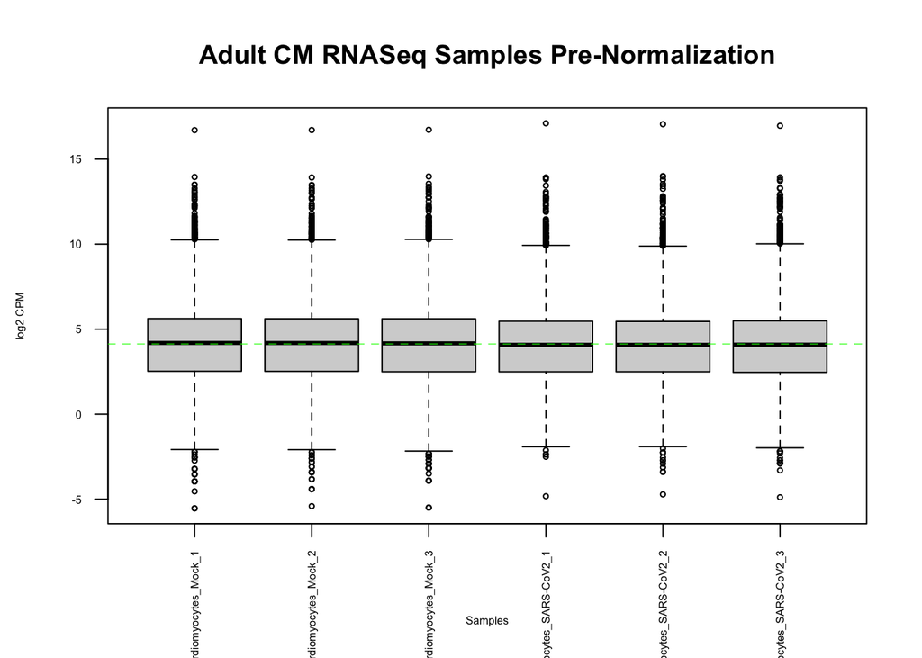

```r
data2plot <- log2(cpm(dt.merged[,3:8]))
boxplot(data2plot, xlab = "Samples", ylab = "log2 CPM",
        las = 2, cex = 0.5, cex.lab = 0.5,
        cex.axis = 0.5, main = "Adult CM RNASeq Samples Pre-Normalization")
#draw the median on each box plot
abline(h = median(apply(data2plot, 2, median)),        col = "green", lwd = 0.6, lty = "dashed")
```

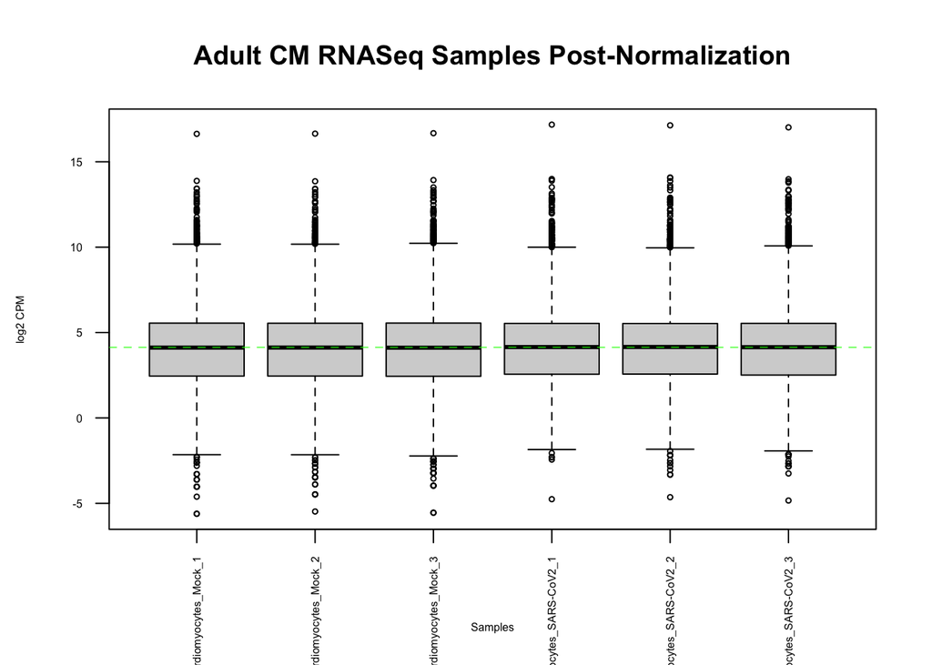

```r
data2plot <- log2(normalized_counts[,1:6])
boxplot(data2plot, xlab = "Samples", ylab = "log2 CPM",
        las = 2, cex = 0.5, cex.lab = 0.5,
        cex.axis = 0.5, main = "Adult CM RNASeq Samples Post-Normalization")
#draw the median on each box plot
abline(h = median(apply(data2plot, 2, median)),
       col = "green", lwd = 0.6, lty = "dashed")
```

#### 3.4 Density plots before and after normalization.

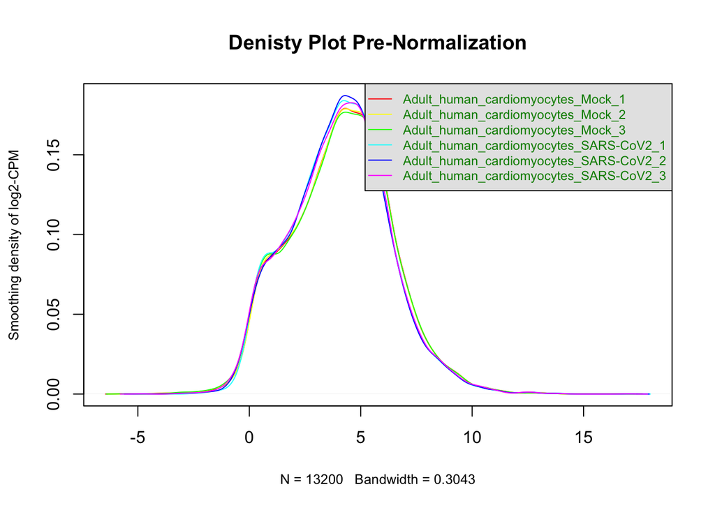

```r
  counts_density <- apply(log2(cpm(dt.merged[,3:8])), 2, density)
  #calculate the limits across all the samples
  xlim <- 0; ylim <- 0
  for (i in 1:length(counts_density)) {
    xlim <- range(c(xlim, counts_density[[i]]$x));
    ylim <- range(c(ylim, counts_density[[i]]$y))
    }
    cols <- rainbow(length(counts_density))
    ltys <- rep(1, length(counts_density))
    #plot the first density plot to initialize the plot
    plot(counts_density[[1]], xlim=xlim, ylim=ylim, type="n",
         ylab="Smoothing density of log2-CPM", main="Denisty Plot Pre-Normalization", cex.lab = 0.8  )
    #plot each line
    for (i in 1:length(counts_density)) lines(counts_density[[i]], col = cols[i])
    #create legend
    legend("topright", colnames(data2plot),
           col=cols, lty=ltys, cex=0.75,
           border ="blue",  text.col = "green4",
           merge = TRUE, bg = "gray90")
```

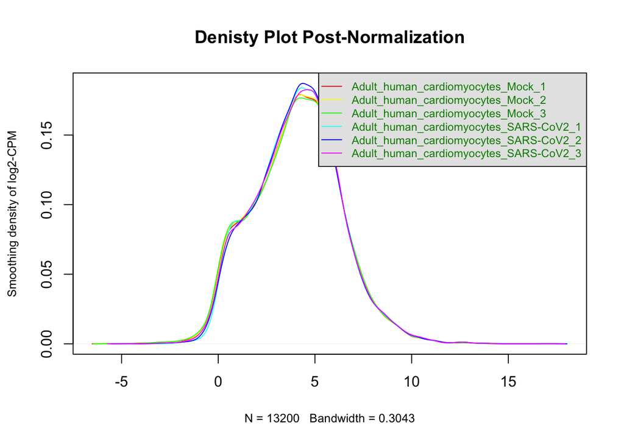

```r
   counts_density <- apply(log2(normalized_counts[,1:6]), 2, density)
  #calculate the limits across all the samples
  xlim <- 0; ylim <- 0
  for (i in 1:length(counts_density)) {
    xlim <- range(c(xlim, counts_density[[i]]$x));
    ylim <- range(c(ylim, counts_density[[i]]$y))
    }
    cols <- rainbow(length(counts_density))
    ltys <- rep(1, length(counts_density))
    #plot the first density plot to initialize the plot
    plot(counts_density[[1]], xlim=xlim, ylim=ylim, type="n",
         ylab="Smoothing density of log2-CPM", main="Denisty Plot Post-Normalization", cex.lab = 0.8  )
    #plot each line
    for (i in 1:length(counts_density)) lines(counts_density[[i]], col = cols[i])
    #create legend
    legend("topright", colnames(data2plot),
           col=cols, lty=ltys, cex=0.75,
           border ="blue",  text.col = "green4",
           merge = TRUE, bg = "gray90")
```

#### 3.5 MDS plot after normalization.

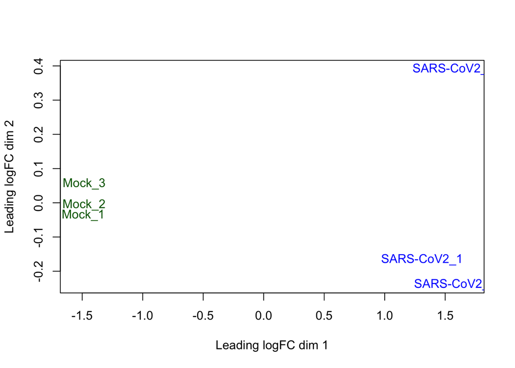

```r
hold <- vector()
for (i in 1:nrow(samples)) {
  lab <-c(samples$condition[i],samples$number[i])
  hold<- c(hold, paste(lab, collapse = "_") )
}
plotMDS(d, labels= hold,
        col = c("darkgreen","blue")[factor(samples$condition)])
```

# 4. Interpretation

-What are the control and test conditions of the dataset?

The controls are healthy adult human cardiomyocytes and the test conditions are adult human cardiomyocytes infected by SARS-CoV2.

-Why is the dataset of interest to you?

SARS-CoV2 is very relevant right now and its effects on us is not fully understood. I want to contribute to potential novel discoveries of how SARS-CoV2 affects our bodies.

Were there expression values that were not unique for specific genes? How did you handle these?

No. From the successfully mapped ids I had no duplicate hgnc symbols.

-Were there expression values that could not be mapped to current HUGO symbols?

Yes, I have 625 in total (253 with “NA” and 372 with an empty string). I chose to keep them because I do not think that not being able to map them is a good enough reason to discard them.

-How many outliers were removed?

After the inital cpm filer the data set went from 57916 to 13200 rows so 44716 in total were discarded.

-How did you handle replicates?

I had no replicates/duplicates other than the gene ids that were not successfully mapped to hgnc symbols.

-What is the final coverage of your dataset?

13200 genes with 625 missing hgnc symbols.